# Modelowanie matematyczne

## Sprawdzanie normalności

```r
residuals <- residuals(step_result)
      normal_test <- ad.test(residuals)
      if (normal_test$p.value < 0.05) {
        "Reszty NIE są zgodne z rozkładem normalnym"
      } else {
        "Reszty są zgodne z rozkładem normalnym"
      }
```

```
## [1] "Reszty są zgodne z rozkładem normalnym"
```

Powyższy kod za pomocą testu normalności Andersona-Darlinga sprawdza czy reszty naszego modelu są lub nie są zgodne z rozkładem normalnym. Warto wspomnieć o założeniach testu normalności Andersona-Darlinga:

-Dystrybucja teoretyczna

-Dane ilościowe

-Brak zakłóceń

-Nieobciążone dane

-Kategorie nieprzekraczalne

-Poziom istotności

## Wykres normalności reszt

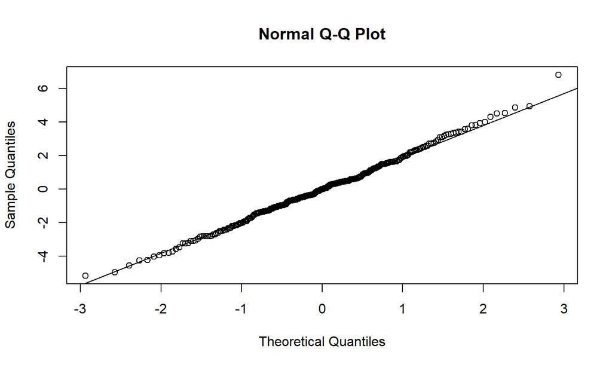

```r
qqnorm(step_result$residuals)
      qqline(step_result$residuals)
```

## Teoretyczne Założenia A.R.L:

## 1. Liniowość

```r
#model_formula <- as.formula("y ~ I(x) + I(x^2) + I(x^3)")
#initial_model <- lm(model_formula, data = data())
```

## 2. Liczba obserwacji

Musi być większa bądź równa liczbie parametrów wyprowadzonych z analizy regresji (współczynniki dla predyktorów, wyraz wolny. W praktyce zakłada się, że powinno być **co najmniej 15, 20 obserwacji** na jedną zmienną w modelu regresji.

## 3. Homoskedastyczność

Założenie o równości wariancji reszt (błędów modelu) dla wszystkich poziomów zmiennych niezależnych. Innymi słowy, oczekujemy, że rozrzut reszt wokół dopasowanej linii jest stabilny i nie zależy od wartości zmiennych niezależnych. NP. dla x^2 + e

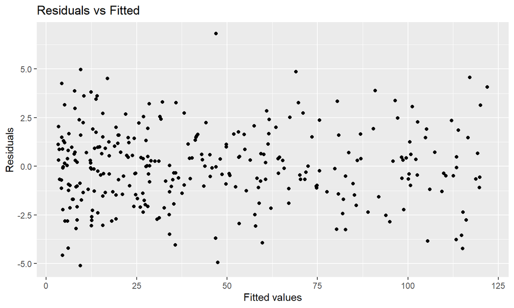

```r
library(ggplot2)
residuals_vs_fitted<-ggplot(data=data,aes(x=fitted(initial_model),y=

residuals(initial_model))) +
 geom_point() +
labs(x ="Fitted values",y="Residuals",title="Residuals vs Fitted")
print(residuals_vs_fitted)
```

## 4. Brak autokorelacji

Reszty modelu są niezależne od siebie. Innymi słowy, brak jest wzorca w pozostałościach, nie występuje zależność pomiędzy resztami dla różnych obserwacji.

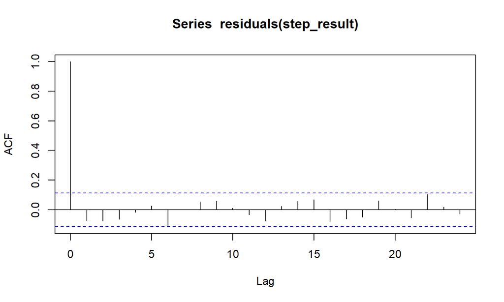

```r
acf(residuals(step_result))
```

## 5. Reszty mają rozkład zbliżony do rozkładu normalnego

Normalność rozkładu reszt możemy oszacować korzystając z testów normalności, takich jak: test Shapiro-Wilka, test Kołmogorowa-Smirnowa. My natomiast używamy testu Andersona-Darlinga.

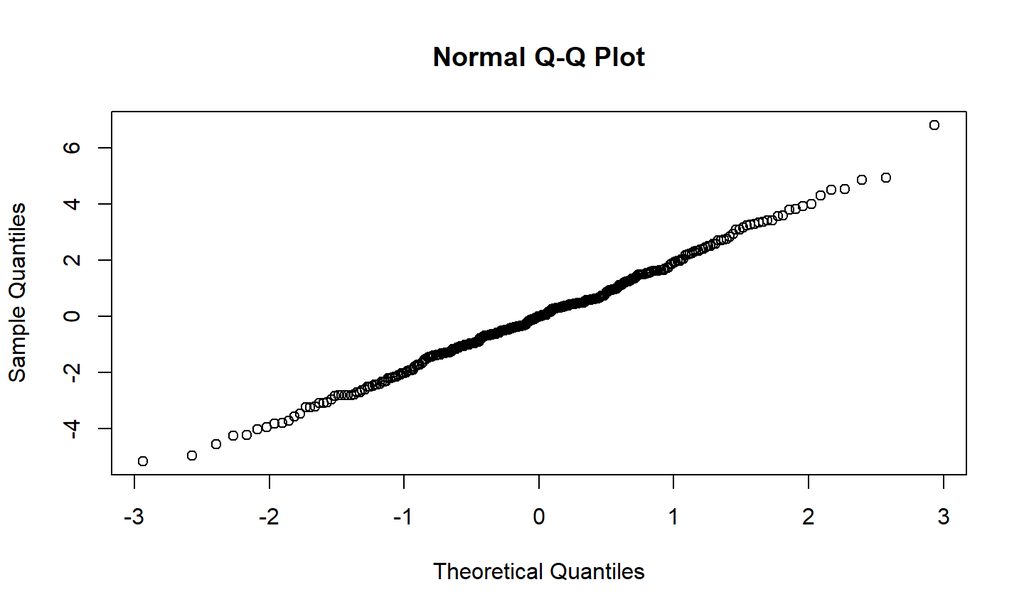

```r
qqnorm(residuals(step_result))
```

## Interfejs Użytkownika (UI)

## Wygląd

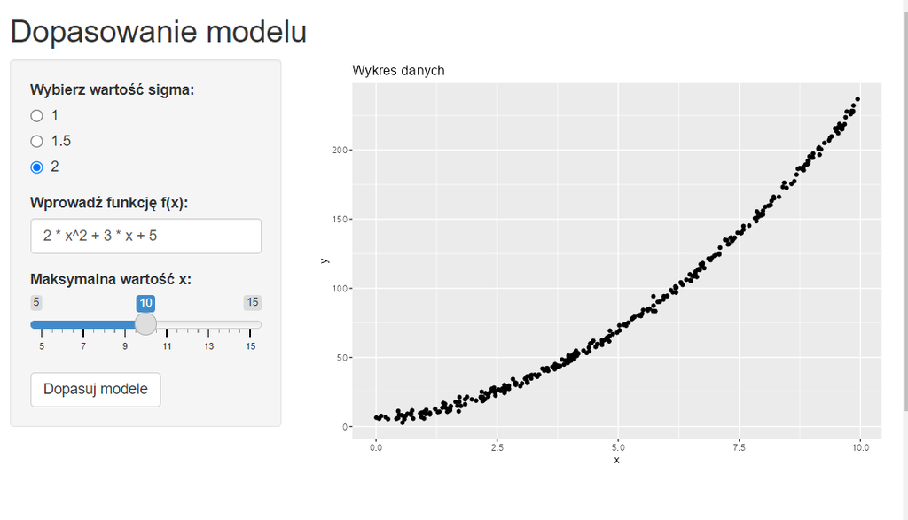

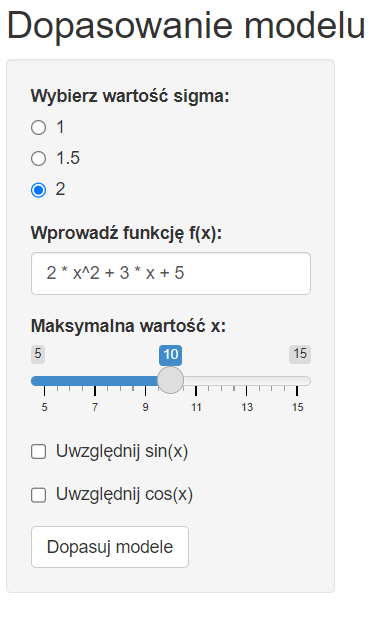

-**RadioButtons (“sigma”):** Pozwala użytkownikowi wybrać wartość parametru sigma, który wpływa na poziom szumu w danych.

-**TextInput (“functionInput”):** Pozwala użytkownikowi wprowadzić funkcję f(x), która reprezentuje relację między zmiennymi.

-**SliderInput (“maxX”):** Pozwala użytkownikowi ustawić maksymalną wartość x w generowanych danych.

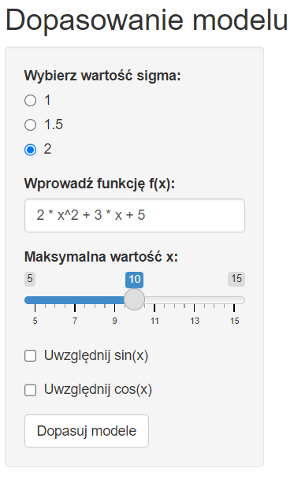

-**CheckboxInputs (“includeSin”, “includeCos”):** Pozwalają użytkownikowi uwzględnić dodatkowe składniki funkcji sinus i cosinus w modelu.

-**ActionButton (“fitButton”):** Uruchamia proces dopasowywania modelu po kliknięciu.

## MainPanel

Zawiera wykresy danych, dopasowanego modelu, podsumowania modelu i wyniki testu normalności.

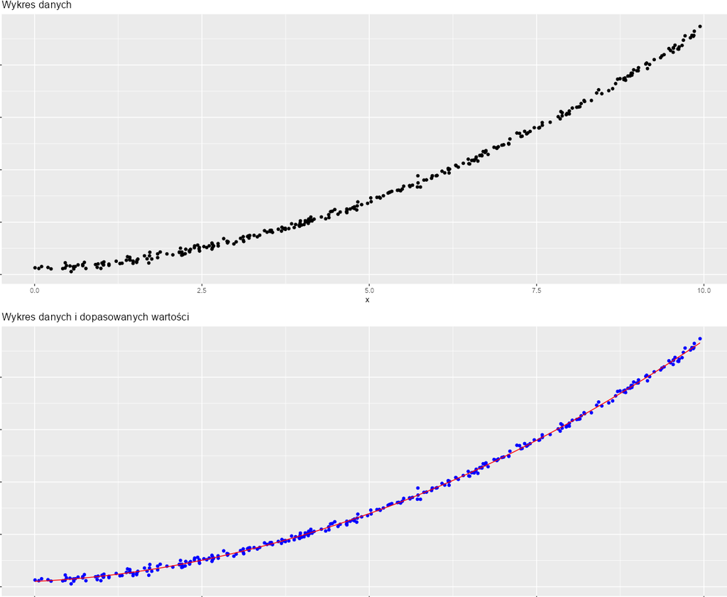

## MainPanel

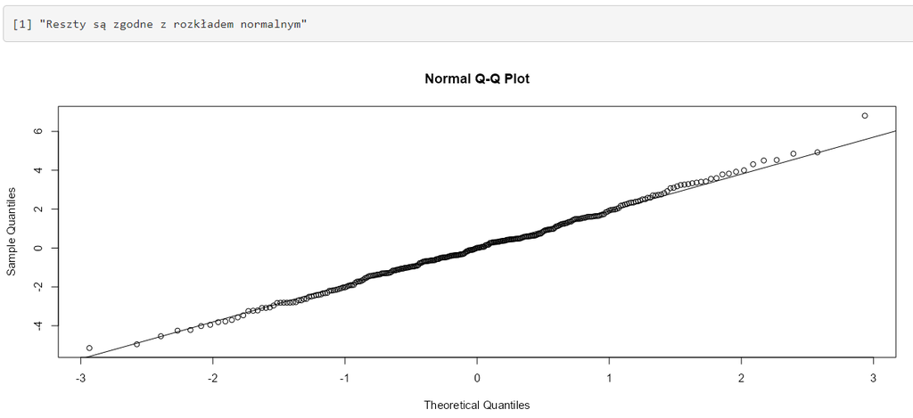

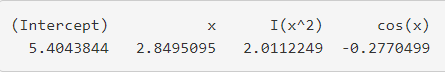

## Źródła

- [link]https://www.naukowiec.org/wiedza/statystyka/zalozenia-analizy-regresji-liniowej_439.html?fbclid=IwAR37ZSTLaO0yb3Uqt9-bFIOD4zSSKe6BeKw2HeDNLU7ABOa8it2DhORC4f8

#### **Podział pracy**

-Szymon Popkiewicz - aplikacja Shiny

-Kacper Prorok - prezentacja